# Project 70 by Team 439

```python
import pandas as pd
import seaborn as sns
import matplotlib.pyplot as plt
```

### Setup: Timing & Evaluation Function

We define a helper function to train models, measure their training/prediction time (latency), and evaluate them using key metrics for fraud detection (Recall, Precision, PR-AUC). This ensures a consistent benchmark across all models.

```python
import time
import pandas as pd
from sklearn.metrics import recall_score, precision_score, roc_auc_score, average_precision_score

# Initialize a dictionary to store results
model_performance = []

def train_and_evaluate(model, model_name, X_train, y_train, X_test, y_test):
    print(f"--- Processing {model_name} ---")

    # 1. Track Training Time
    start_time = time.time()
    model.fit(X_train, y_train)
    train_time = time.time() - start_time
    print(f"Training Time: {train_time:.2f} seconds")

    # 2. Track Prediction Time (Latency is crucial for fraud!)
    start_time = time.time()
    y_pred = model.predict(X_test)
    y_proba = model.predict_proba(X_test)[:, 1]
    pred_time = time.time() - start_time
    print(f"Prediction Time: {pred_time:.2f} seconds")

    # 3. Calculate Metrics
    recall = recall_score(y_test, y_pred)
    precision = precision_score(y_test, y_pred)
    roc_auc = roc_auc_score(y_test, y_proba)
    pr_auc = average_precision_score(y_test, y_proba)

    # 4. Save to dictionary
    model_performance.append({
        'Model': model_name,
        'Training Time (s)': train_time,
        'Prediction Time (s)': pred_time,
        'Recall': recall,
        'Precision': precision,
        'ROC-AUC': roc_auc,
        'PR-AUC': pr_auc
    })
```

# 1. Understanding of the dataset

```python
df = pd.read_csv("Base.csv")
df.head()
```

|  | fraud_bool | income | name_email_similarity | prev_address_months_count | current_address_months_count | customer_age | days_since_request | intended_balcon_amount | payment_type | zip_count_4w | ... | has_other_cards | proposed_credit_limit | foreign_request | source | session_length_in_minutes | device_os | keep_alive_session | device_distinct_emails_8w | device_fraud_count | month |
| --- | --- | --- | --- | --- | --- | --- | --- | --- | --- | --- | --- | --- | --- | --- | --- | --- | --- | --- | --- | --- | --- |
| 0 | 1 | 0.9 | 0.166828 | -1 | 88 | 50 | 0.020925 | -1.331345 | AA | 769 | ... | 0 | 500.0 | 0 | INTERNET | 3.888115 | windows | 0 | 1 | 0 | 7 |
| 1 | 1 | 0.9 | 0.296286 | -1 | 144 | 50 | 0.005418 | -0.816224 | AB | 366 | ... | 0 | 1500.0 | 0 | INTERNET | 31.798819 | windows | 0 | 1 | 0 | 7 |
| 2 | 1 | 0.9 | 0.044985 | -1 | 132 | 40 | 3.108549 | -0.755728 | AC | 870 | ... | 0 | 200.0 | 0 | INTERNET | 4.728705 | other | 0 | 1 | 0 | 7 |
| 3 | 1 | 0.9 | 0.159511 | -1 | 22 | 50 | 0.019079 | -1.205124 | AB | 810 | ... | 1 | 200.0 | 0 | INTERNET | 2.047904 | linux | 0 | 1 | 0 | 7 |
| 4 | 1 | 0.9 | 0.596414 | -1 | 218 | 50 | 0.004441 | -0.773276 | AB | 890 | ... | 0 | 1500.0 | 0 | INTERNET | 3.775225 | macintosh | 1 | 1 | 0 | 7 |

5 rows × 32 columns

```python
from pathlib import Path

csv_path = Path("Base.csv") if Path("Base.csv").exists() else Path("base.csv")
print(f"Loaded file: {csv_path.resolve() if csv_path.exists() else 'base.csv (path check skipped)'}")
print("Shape (rows, cols):", df.shape)
print("\nFirst 3 columns:", list(df.columns[:3]))
print("Total columns:", len(df.columns))

print("\nDtype counts:")
print(df.dtypes.value_counts())
mem_mb = df.memory_usage(deep=True).sum() / (1024**2)
print(f"\nEstimated memory usage: {mem_mb:.2f} MB")

dup_count = df.duplicated().sum()
print(f"\nDuplicate rows: {dup_count}")
```

```
Loaded file: C:\Users\pwart\OneDrive\Documents\ProjetPI²\Base.csv
Shape (rows, cols): (1000000, 32)

First 3 columns: ['fraud_bool', 'income', 'name_email_similarity']
Total columns: 32

Dtype counts:
int64      18
float64     9
object      5
Name: count, dtype: int64

Estimated memory usage: 496.60 MB

Duplicate rows: 0
```

**→ 1M rows × 32 columns. No duplicates.**

```python
df.info()
```

```
<class 'pandas.core.frame.DataFrame'>
RangeIndex: 1000000 entries, 0 to 999999
Data columns (total 32 columns):
 #   Column                            Non-Null Count    Dtype
---  ------                            --------------    -----
 0   fraud_bool                        1000000 non-null  int64
 1   income                            1000000 non-null  float64
 2   name_email_similarity             1000000 non-null  float64
 3   prev_address_months_count         1000000 non-null  int64
 4   current_address_months_count      1000000 non-null  int64
 5   customer_age                      1000000 non-null  int64
 6   days_since_request                1000000 non-null  float64
 7   intended_balcon_amount            1000000 non-null  float64
 8   payment_type                      1000000 non-null  object
 9   zip_count_4w                      1000000 non-null  int64
```

[output cut: 24 more lines]

```python
if "fraud_bool" in df.columns:
    cls_counts = df["fraud_bool"].value_counts(dropna=False).sort_index()
    cls_pct = df["fraud_bool"].value_counts(normalize=True, dropna=False).sort_index() * 100
    print("Counts by class (0/1):\n", cls_counts)
    print("\nClass percentages (%):\n", cls_pct.round(2))
    minority_rate = cls_pct.min()
    majority_rate = cls_pct.max()
    print(f"\nMajority-class baseline accuracy: {majority_rate:.2f}%")
else:
    print("Column 'fraud_bool' not found. Please set TARGET variable name correctly.")
```

```
Counts by class (0/1):
 fraud_bool
0    988971
1     11029
Name: count, dtype: int64

Class percentages (%):
 fraud_bool
0    98.9
1     1.1
Name: proportion, dtype: float64

Majority-class baseline accuracy: 98.90%
```

**→ Fraud rate = 1.1% (highly imbalanced). Need to use class weights/resampling and focus on recall/precision.**

```python
df.isnull().sum().sort_values(ascending=False)
```

```
fraud_bool                          0
income                              0
device_fraud_count                  0
device_distinct_emails_8w           0
keep_alive_session                  0
device_os                           0
session_length_in_minutes           0
source                              0
foreign_request                     0
proposed_credit_limit               0
has_other_cards                     0
bank_months_count                   0
phone_mobile_valid                  0
phone_home_valid                    0
housing_status                      0
email_is_free                       0
credit_risk_score                   0
employment_status                   0
date_of_birth_distinct_emails_4w    0
bank_branch_count_8w                0
velocity_4w                         0
velocity_24h                        0
velocity_6h                         0
zip_count_4w                        0
payment_type                        0
intended_balcon_amount              0
days_since_request                  0
customer_age                        0
current_address_months_count        0
prev_address_months_count           0
name_email_similarity               0
month                               0
dtype: int64
```

```python
na_counts = df.isna().sum()
na_pct = (na_counts / len(df) * 100).round(2)
na_df = (
    pd.DataFrame({"missing": na_counts, "%": na_pct})
    .sort_values(["missing", "%"], ascending=False)
)
print(na_df.head(20))

top = na_df[na_df["missing"] > 0].head(20)
if not top.empty:
    plt.figure(figsize=(10, 5))
    sns.barplot(x=top.index, y=top["%"], color="salmon")
    plt.title("Top missing columns (% of rows)")
    plt.ylabel("% missing")
    plt.xlabel("Column")
    plt.xticks(rotation=45, ha="right")
    plt.tight_layout()
    plt.show()
else:
    print("No missing values detected.")
```

```
                                  missing    %
fraud_bool                              0  0.0
income                                  0  0.0
name_email_similarity                   0  0.0
prev_address_months_count               0  0.0
current_address_months_count            0  0.0
customer_age                            0  0.0
days_since_request                      0  0.0
intended_balcon_amount                  0  0.0
payment_type                            0  0.0
zip_count_4w                            0  0.0
velocity_6h                             0  0.0
velocity_24h                            0  0.0
velocity_4w                             0  0.0
bank_branch_count_8w                    0  0.0
date_of_birth_distinct_emails_4w        0  0.0
employment_status                       0  0.0
credit_risk_score                       0  0.0
email_is_free                           0  0.0
housing_status                          0  0.0
phone_home_valid                        0  0.0
No missing values detected.
```

**→ No missing values detected.**

```python
cat_cols = df.select_dtypes(include=["object", "category"]).columns.tolist()
if cat_cols:
    card = df[cat_cols].nunique(dropna=False).sort_values(ascending=False)
    print("Top 15 categorical columns by unique values:\n")
    print(card.head(15))
else:
    print("No categorical columns detected.")
```

```
Top 15 categorical columns by unique values:

employment_status    7
housing_status       7
payment_type         5
device_os            5
source               2
dtype: int64
```

**→ Low cardinality (max 7 unique values). One-hot encoding is fine.**

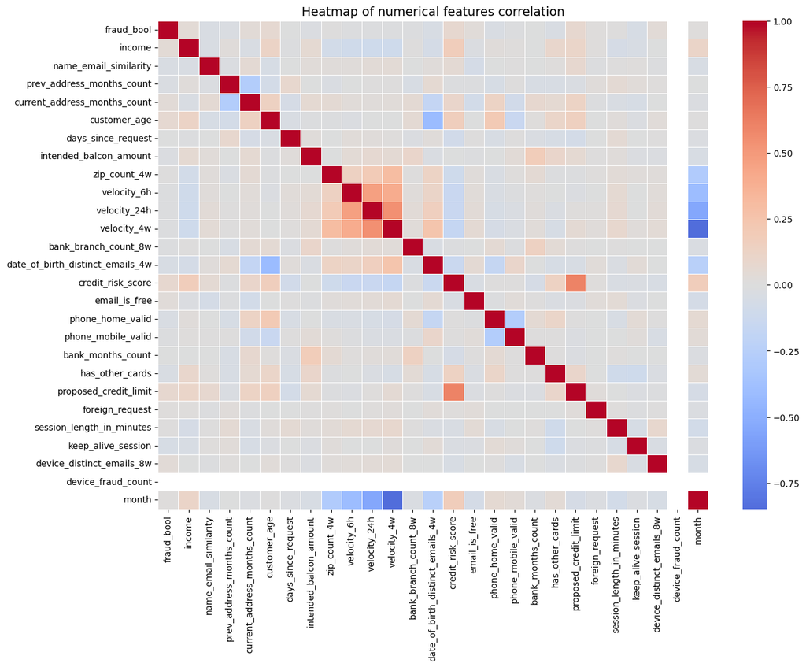

```python
df_numeric = df.select_dtypes(include=['int64', 'float64'])

corr_matrix = df_numeric.corr()

plt.figure(figsize=(14, 10))
sns.heatmap(corr_matrix, annot=False, cmap="coolwarm", center=0, linewidths=0.5)
plt.title("Heatmap of numerical features correlation", fontsize=14)
plt.show()
```

```python
corr_fraudbool =df.corr(numeric_only=True)["fraud_bool"]
positive_corr = corr_fraudbool[corr_fraudbool > 0]
print(positive_corr)
```

```
fraud_bool                      1.000000
income                          0.045079
current_address_months_count    0.033701
customer_age                    0.062959
days_since_request              0.000567
zip_count_4w                    0.005212
credit_risk_score               0.070624
email_is_free                   0.027758
proposed_credit_limit           0.068907
foreign_request                 0.016885
session_length_in_minutes       0.008999
device_distinct_emails_8w       0.035704
month                           0.013250
Name: fraud_bool, dtype: float64
```

[figure not shown]

```python
if "fraud_bool" in df.columns:
    corr = df.corr(numeric_only=True)["fraud_bool"].drop(labels=["fraud_bool"]).sort_values()
    top_neg = corr.head(10)
    top_pos = corr.tail(10)
    fig, axes = plt.subplots(1, 2, figsize=(14, 5), sharey=True)
    sns.barplot(x=top_neg.values, y=top_neg.index, ax=axes[0], color="steelblue")
    axes[0].set_title("Top negative correlations")
    axes[0].set_xlabel("Correlation")
    sns.barplot(x=top_pos.values, y=top_pos.index, ax=axes[1], color="indianred")
    axes[1].set_title("Top positive correlations")
    axes[1].set_xlabel("Correlation")
    plt.tight_layout()
    plt.show()
else:
    print("Column 'fraud_bool' not found.")
```

```python
object_cols = df.select_dtypes(include=['object'])

df_encoded = pd.get_dummies(object_cols, drop_first=True)

corr_with_fraud = df_encoded.corrwith(df['fraud_bool']).sort_values(ascending=False)

corr_positive = corr_with_fraud[corr_with_fraud > 0]

print("Encoded categorical features with positive correlation with fraud_bool:\n")
print(corr_positive)
```

```
Encoded categorical features with positive correlation with fraud_bool:

device_os_windows       0.078263
payment_type_AC         0.031510
employment_status_CC    0.025899
device_os_macintosh     0.006719
source_TELEAPP          0.003922
payment_type_AB         0.001629
employment_status_CG    0.000902
device_os_x11           0.000145
dtype: float64
```

**→ Weak correlations overall. Strongest: credit_risk_score (0.07), device_os_windows (0.08).**

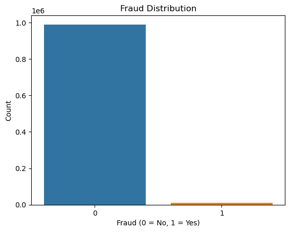

```python
sns.countplot(x="fraud_bool", data=df)
plt.title("Fraud Distribution")
plt.xlabel("Fraud (0 = No, 1 = Yes)")
plt.ylabel("Count")
plt.show()
```

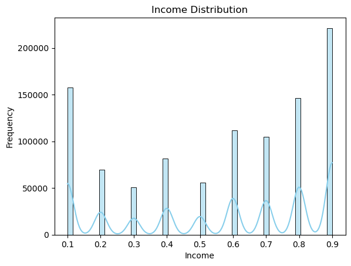

```python
sns.histplot(df["income"], bins=50, kde=True, color="skyblue")
plt.title("Income Distribution")
plt.xlabel("Income")
plt.ylabel("Frequency")
plt.show()
```

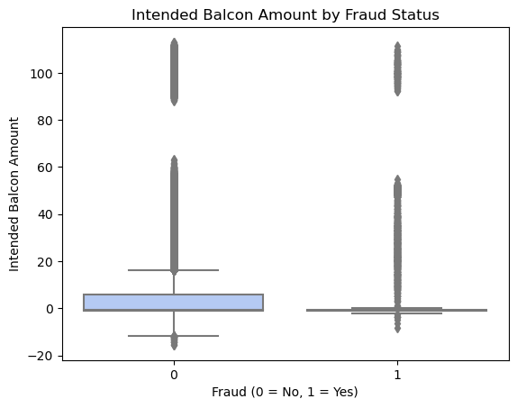

```python
sns.boxplot(x="fraud_bool", y="intended_balcon_amount", data=df, palette="coolwarm")
plt.title("Intended Balcon Amount by Fraud Status")
plt.xlabel("Fraud (0 = No, 1 = Yes)")
plt.ylabel("Intended Balcon Amount")
plt.show()
```

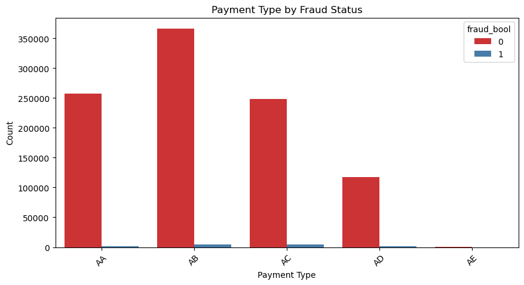

```python
plt.figure(figsize=(10,5))
sns.countplot(x="payment_type", hue="fraud_bool", data=df, palette="Set1")
plt.title("Payment Type by Fraud Status")
plt.xlabel("Payment Type")
plt.ylabel("Count")
plt.xticks(rotation=45)
plt.show()
```

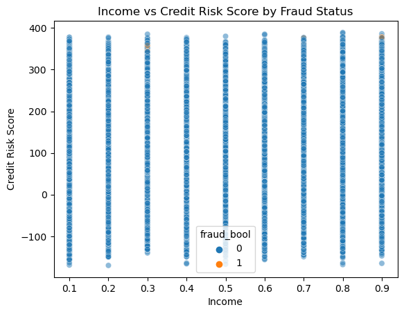

```python
sns.scatterplot(x="income", y="credit_risk_score", hue="fraud_bool", data=df, alpha=0.5)
plt.title("Income vs Credit Risk Score by Fraud Status")
plt.xlabel("Income")
plt.ylabel("Credit Risk Score")
plt.show()
```

## Conclusion

- Dataset is clean (no missing values, no duplicates)
- Severe class imbalance → use class weights and optimize for recall/precision
- Categorical features have low cardinality → one-hot encoding
- Correlations are weak but we'll keep all features for modeling

# 2. Preprocessing

```python
from sklearn.model_selection import train_test_split
from sklearn.preprocessing import StandardScaler

X = df.drop('fraud_bool', axis=1)
y = df['fraud_bool']

# Drop rows with missing values
X = X.dropna()
y = y[X.index]


print(f"Features shape: {X.shape}")
print(f"Target distribution:\n{y.value_counts()}")
```

```
Features shape: (1000000, 31)
Target distribution:
fraud_bool
0    988971
1     11029
Name: count, dtype: int64
```

```python
# One-hot encode categorical features
X_encoded = pd.get_dummies(X, drop_first=True)

print(f"Shape after encoding: {X_encoded.shape}")
print(f"New columns created: {X_encoded.shape[1] - X.shape[1]}")
```

```
Shape after encoding: (1000000, 47)
New columns created: 16
```

```python
# Stratified train/test split (80/20)
X_train, X_test, y_train, y_test = train_test_split(
    X_encoded, y,
    test_size=0.2,
    random_state=42,
    stratify=y
)

print(f"Train set: {X_train.shape[0]} samples")
print(f"Test set: {X_test.shape[0]} samples")
print(f"\nTrain fraud rate: {y_train.mean():.3%}")
print(f"Test fraud rate: {y_test.mean():.3%}")
```

```
Train set: 800000 samples
Test set: 200000 samples

Train fraud rate: 1.103%
Test fraud rate: 1.103%
```

**→ Stratified split preserves 1.1% fraud rate in both train and test sets.**

```python
# Scale numerical features (for models that need it like LogReg, SVM)
scaler = StandardScaler()
X_train_scaled = scaler.fit_transform(X_train)
X_test_scaled = scaler.transform(X_test)

print("Features scaled using StandardScaler")
print(f"Train mean: {X_train_scaled.mean():.4f}, std: {X_train_scaled.std():.4f}")
```

```
Features scaled using StandardScaler
Train mean: -0.0000, std: 0.9893
```

### 2.1 Handling Imbalance: SMOTE-Tomek

Since the dataset is highly imbalanced (1.1% fraud), standard training might bias models towards the majority class. We use **SMOTE-Tomek**, a hybrid resampling technique:

1. **SMOTE** (Synthetic Minority Over-sampling Technique) creates synthetic fraud examples to increase their representation.
2. **Tomek Links** removes ambiguous samples near the decision boundary to clean up the classes.

```python
from imblearn.combine import SMOTETomek
from imblearn.under_sampling import RandomUnderSampler
from imblearn.pipeline import Pipeline
from collections import Counter

# 1. Define a pipeline
# Step A: Randomly reduce Non-Fraud so the ratio is 1:10 (Fraud:Non-Fraud)
# This drops your dataset from ~1,000,000 to ~100,000 rows. FAST.
under = RandomUnderSampler(sampling_strategy=0.1, random_state=42)

# Step B: Apply SMOTE-Tomek only on this smaller, cleaner dataset
# sampling_strategy=0.5 means we boost fraud up to 50% of the non-fraud count.
smt = SMOTETomek(sampling_strategy=0.5, random_state=42, n_jobs=-1)

# 2. Run the Pipeline
pipeline = Pipeline(steps=[('under', under), ('smt', smt)])

print("Original dataset shape:", Counter(y_train))
print("Running optimized Hybrid Sampling (Fast)...")

start = time.time()
X_train_smt, y_train_smt = pipeline.fit_resample(X_train_scaled, y_train)
end = time.time()

print(f"Resampling finished in {end - start:.2f} seconds")
print("New dataset shape:", Counter(y_train_smt))
```

```
Original dataset shape: Counter({0: 791177, 1: 8823})
Running optimized Hybrid Sampling (Fast)...
Resampling finished in 49.22 seconds
New dataset shape: Counter({0: 88193, 1: 44078})
```

# 3. Model Training and Evaluation

```python
from sklearn.linear_model import LogisticRegression
from sklearn.ensemble import RandomForestClassifier
from sklearn.metrics import classification_report, confusion_matrix, roc_auc_score, precision_recall_curve, auc

# We'll start with these two models
print("Models ready for training")
```

```
Models ready for training
```

## 3.1 Logistic Regression

```python
from sklearn.model_selection import GridSearchCV
# --- 1. Logistic Regression on Original Data (with class_weight='balanced') ---
lr_params = {
    'C': [0.01, 0.1, 1, 10],
    'penalty': ['l1', 'l2'],
    'solver': ['liblinear'],
    'class_weight': ['balanced']
}

lr = LogisticRegression(max_iter=1000, random_state=42)
lr_grid = GridSearchCV(lr, lr_params, cv=3, scoring='recall', n_jobs=1, verbose=1)

print("Training Logistic Regression (Base) with GridSearch...")
lr_grid.fit(X_train_scaled, y_train)

print(f"Best params (Base): {lr_grid.best_params_}")
print(f"Best CV recall (Base): {lr_grid.best_score_:.4f}")

train_and_evaluate(lr_grid.best_estimator_, "Logistic Regression (Base)", X_train_scaled, y_train, X_test_scaled, y_test)

# --- 2. Logistic Regression on SMOTE Data (no class_weight) ---
lr_params_smt = {
    'C': [0.01, 0.1, 1, 10],
    'penalty': ['l1', 'l2'],
    'solver': ['liblinear'],
    'class_weight': [None] # SMOTE already handled imbalance
}

lr_smt = LogisticRegression(max_iter=1000, random_state=42)
lr_grid_smt = GridSearchCV(lr_smt, lr_params_smt, cv=3, scoring='recall', n_jobs=1, verbose=1)

print("\nTraining Logistic Regression (SMOTE) with GridSearch...")
lr_grid_smt.fit(X_train_smt, y_train_smt)

print(f"Best params (SMOTE): {lr_grid_smt.best_params_}")
print(f"Best CV recall (SMOTE): {lr_grid_smt.best_score_:.4f}")

train_and_evaluate(lr_grid_smt.best_estimator_, "Logistic Regression (SMOTE)", X_train_smt, y_train_smt, X_test_scaled, y_test)
```

```
Training Logistic Regression (Base) with GridSearch...
Fitting 3 folds for each of 8 candidates, totalling 24 fits
Best params (Base): {'C': 0.01, 'class_weight': 'balanced', 'penalty': 'l1', 'solver': 'liblinear'}
Best CV recall (Base): 0.7891
--- Processing Logistic Regression (Base) ---
Training Time: 11.15 seconds
Prediction Time: 0.04 seconds

Training Logistic Regression (SMOTE) with GridSearch...
Fitting 3 folds for each of 8 candidates, totalling 24 fits
Best params (SMOTE): {'C': 0.01, 'class_weight': None, 'penalty': 'l2', 'solver': 'liblinear'}
Best CV recall (SMOTE): 0.6973
--- Processing Logistic Regression (SMOTE) ---
Training Time: 1.04 seconds
Prediction Time: 0.03 seconds
```

## 3.2 Random Forest

```python
# --- 1. Random Forest on Original Data ---
rf_params = {
    'n_estimators': [100],
    'max_depth': [10, 20],
    'min_samples_split': [2],
    'min_samples_leaf': [1],
    'class_weight': ['balanced']
}

rf = RandomForestClassifier(random_state=42, n_jobs=-1)
rf_grid = GridSearchCV(rf, rf_params, cv=3, scoring='recall', n_jobs=-1, verbose=1)

print("Training Random Forest (Base) with GridSearch...")
rf_grid.fit(X_train, y_train)

print(f"Best params (Base): {rf_grid.best_params_}")
print(f"Best CV recall (Base): {rf_grid.best_score_:.4f}")

train_and_evaluate(rf_grid.best_estimator_, "Random Forest (Base)", X_train, y_train, X_test, y_test)

# --- 2. Random Forest on SMOTE Data ---
rf_params_smt = {
    'n_estimators': [100],
    'max_depth': [10, 20],
    'min_samples_split': [2],
    'min_samples_leaf': [1],
    'class_weight': [None]
}

rf_smt = RandomForestClassifier(random_state=42, n_jobs=-1)
rf_grid_smt = GridSearchCV(rf_smt, rf_params_smt, cv=3, scoring='recall', n_jobs=-1, verbose=1)

print("\nTraining Random Forest (SMOTE) with GridSearch...")
# Note: X_train_smt is scaled, but RF handles it fine.
rf_grid_smt.fit(X_train_smt, y_train_smt)

print(f"Best params (SMOTE): {rf_grid_smt.best_params_}")
print(f"Best CV recall (SMOTE): {rf_grid_smt.best_score_:.4f}")

train_and_evaluate(rf_grid_smt.best_estimator_, "Random Forest (SMOTE)", X_train_smt, y_train_smt, X_test_scaled, y_test)
```

```
Training Random Forest (Base) with GridSearch...
Fitting 3 folds for each of 2 candidates, totalling 6 fits
Best params (Base): {'class_weight': 'balanced', 'max_depth': 10, 'min_samples_leaf': 1, 'min_samples_split': 2, 'n_estimators': 100}
Best CV recall (Base): 0.6771
--- Processing Random Forest (Base) ---
Training Time: 131.03 seconds
Prediction Time: 2.93 seconds

Training Random Forest (SMOTE) with GridSearch...
Fitting 3 folds for each of 2 candidates, totalling 6 fits
Best params (SMOTE): {'class_weight': None, 'max_depth': 20, 'min_samples_leaf': 1, 'min_samples_split': 2, 'n_estimators': 100}
Best CV recall (SMOTE): 0.8629
--- Processing Random Forest (SMOTE) ---
Training Time: 34.34 seconds
Prediction Time: 5.61 seconds
```

## 3.3 XGBoost

```python
import xgboost as xgb
from sklearn.ensemble import GradientBoostingClassifier

# --- 1. XGBoost on Original Data ---
scale_pos_weight = (y_train == 0).sum() / (y_train == 1).sum()

xgb_params = {
    'n_estimators': [100],
    'max_depth': [3, 5],
    'learning_rate': [0.1],
    'scale_pos_weight': [scale_pos_weight]
}

xgb_model = xgb.XGBClassifier(random_state=42, eval_metric='logloss')
xgb_grid = GridSearchCV(xgb_model, xgb_params, cv=3, scoring='recall', n_jobs=-1, verbose=1)

print("Training XGBoost (Base) with GridSearch...")
xgb_grid.fit(X_train, y_train)

print(f"Best params (Base): {xgb_grid.best_params_}")
print(f"Best CV recall (Base): {xgb_grid.best_score_:.4f}")

train_and_evaluate(xgb_grid.best_estimator_, "XGBoost (Base)", X_train, y_train, X_test, y_test)

# --- 2. XGBoost on SMOTE Data ---
xgb_params_smt = {
    'n_estimators': [100],
    'max_depth': [3, 5],
    'learning_rate': [0.1],
    'scale_pos_weight': [1] # Balanced by SMOTE
}

xgb_model_smt = xgb.XGBClassifier(random_state=42, eval_metric='logloss')
xgb_grid_smt = GridSearchCV(xgb_model_smt, xgb_params_smt, cv=3, scoring='recall', n_jobs=-1, verbose=1)

print("\nTraining XGBoost (SMOTE) with GridSearch...")
xgb_grid_smt.fit(X_train_smt, y_train_smt)

print(f"Best params (SMOTE): {xgb_grid_smt.best_params_}")
print(f"Best CV recall (SMOTE): {xgb_grid_smt.best_score_:.4f}")

train_and_evaluate(xgb_grid_smt.best_estimator_, "XGBoost (SMOTE)", X_train_smt, y_train_smt, X_test_scaled, y_test)
```

```
Training XGBoost (Base) with GridSearch...
Fitting 3 folds for each of 2 candidates, totalling 6 fits
```

```
Best params (Base): {'learning_rate': 0.1, 'max_depth': 3, 'n_estimators': 100, 'scale_pos_weight': np.float64(89.67210699308625)}
Best CV recall (Base): 0.7963
--- Processing XGBoost (Base) ---
Training Time: 10.98 seconds
Prediction Time: 0.80 seconds

Training XGBoost (SMOTE) with GridSearch...
Fitting 3 folds for each of 2 candidates, totalling 6 fits
Best params (SMOTE): {'learning_rate': 0.1, 'max_depth': 5, 'n_estimators': 100, 'scale_pos_weight': 1}
Best CV recall (SMOTE): 0.8046
--- Processing XGBoost (SMOTE) ---
Training Time: 2.25 seconds
Prediction Time: 0.81 seconds
```

## 3.4 Gradient Boosting

```python
# --- 1. Gradient Boosting on Original Data ---
gb_params = {
    'n_estimators': [100],
    'learning_rate': [0.01, 0.1],
    'max_depth': [3, 5],
    'subsample': [0.8]
}

gb = GradientBoostingClassifier(random_state=42)
gb_grid = GridSearchCV(gb, gb_params, cv=3, scoring='recall', n_jobs=-1, verbose=1)

print("Training Gradient Boosting (Base) with GridSearch...")
gb_grid.fit(X_train, y_train)

print(f"Best params (Base): {gb_grid.best_params_}")
print(f"Best CV recall (Base): {gb_grid.best_score_:.4f}")

train_and_evaluate(gb_grid.best_estimator_, "Gradient Boosting (Base)", X_train, y_train, X_test, y_test)

# --- 2. Gradient Boosting on SMOTE Data ---
gb_params_smt = {
    'n_estimators': [100],
    'learning_rate': [0.01, 0.1],
    'max_depth': [3, 5],
    'subsample': [0.8]
}

gb_smt = GradientBoostingClassifier(random_state=42)
gb_grid_smt = GridSearchCV(gb_smt, gb_params_smt, cv=3, scoring='recall', n_jobs=-1, verbose=1)

print("\nTraining Gradient Boosting (SMOTE) with GridSearch...")
gb_grid_smt.fit(X_train_smt, y_train_smt)

print(f"Best params (SMOTE): {gb_grid_smt.best_params_}")
print(f"Best CV recall (SMOTE): {gb_grid_smt.best_score_:.4f}")

train_and_evaluate(gb_grid_smt.best_estimator_, "Gradient Boosting (SMOTE)", X_train_smt, y_train_smt, X_test_scaled, y_test)
```

```
Training Gradient Boosting (Base) with GridSearch...
Fitting 3 folds for each of 4 candidates, totalling 12 fits
Best params (Base): {'learning_rate': 0.1, 'max_depth': 5, 'n_estimators': 100, 'subsample': 0.8}
Best CV recall (Base): 0.0407
--- Processing Gradient Boosting (Base) ---
```

[output not shown]

[output cut: 11 more lines]

[output not shown]

## 3.5 LightGBM

```python
import lightgbm as lgb

# --- 1. LightGBM on Original Data ---
lgb_params = {
    'n_estimators': [100],
    'learning_rate': [0.01, 0.1],
    'max_depth': [5, 7],
    'num_leaves': [31],
    'class_weight': ['balanced']
}

lgb_model = lgb.LGBMClassifier(random_state=42, verbose=-1)
lgb_grid = GridSearchCV(lgb_model, lgb_params, cv=3, scoring='recall', n_jobs=-1, verbose=1)

print("Training LightGBM (Base) with GridSearch...")
lgb_grid.fit(X_train, y_train)

print(f"Best params (Base): {lgb_grid.best_params_}")
print(f"Best CV recall (Base): {lgb_grid.best_score_:.4f}")

train_and_evaluate(lgb_grid.best_estimator_, "LightGBM (Base)", X_train, y_train, X_test, y_test)

# --- 2. LightGBM on SMOTE Data ---
lgb_params_smt = {
    'n_estimators': [100],
    'learning_rate': [0.01, 0.1],
    'max_depth': [5, 7],
    'num_leaves': [31],
    'class_weight': [None]
}

lgb_model_smt = lgb.LGBMClassifier(random_state=42, verbose=-1)
lgb_grid_smt = GridSearchCV(lgb_model_smt, lgb_params_smt, cv=3, scoring='recall', n_jobs=-1, verbose=1)

print("\nTraining LightGBM (SMOTE) with GridSearch...")
lgb_grid_smt.fit(X_train_smt, y_train_smt)

print(f"Best params (SMOTE): {lgb_grid_smt.best_params_}")
print(f"Best CV recall (SMOTE): {lgb_grid_smt.best_score_:.4f}")

train_and_evaluate(lgb_grid_smt.best_estimator_, "LightGBM (SMOTE)", X_train_smt, y_train_smt, X_test_scaled, y_test)
```

```
Training LightGBM (Base) with GridSearch...
Fitting 3 folds for each of 4 candidates, totalling 12 fits
Best params (Base): {'class_weight': 'balanced', 'learning_rate': 0.1, 'max_depth': 7, 'n_estimators': 100, 'num_leaves': 31}
Best CV recall (Base): 0.7800
--- Processing LightGBM (Base) ---
Training Time: 14.42 seconds
Prediction Time: 2.83 seconds

Training LightGBM (SMOTE) with GridSearch...
Fitting 3 folds for each of 4 candidates, totalling 12 fits
Best params (SMOTE): {'class_weight': None, 'learning_rate': 0.1, 'max_depth': 5, 'n_estimators': 100, 'num_leaves': 31}
Best CV recall (SMOTE): 0.8038
--- Processing LightGBM (SMOTE) ---
Training Time: 2.95 seconds
```

```
Prediction Time: 1.96 seconds
```

```
--- Model Performance Comparison ---
                      Model  Training Time (s)  Prediction Time (s)   Recall  Precision  ROC-AUC   PR-AUC
             XGBoost (Base)          10.978894             0.798483 0.788305   0.047032 0.888671 0.161259
 Logistic Regression (Base)          11.150077             0.043308 0.784678   0.043078 0.873521 0.128920
            LightGBM (Base)          14.421338             2.828335 0.775159   0.050861 0.893612 0.166271
       Random Forest (Base)         131.029461             2.928577 0.691296   0.053603 0.870620 0.125824
Logistic Regression (SMOTE)           1.035401             0.029743 0.632366   0.064829 0.872008 0.130205
            XGBoost (SMOTE)           2.252729             0.806766 0.396192   0.140266 0.886332 0.152218
           LightGBM (SMOTE)           2.949282             1.958735 0.385313   0.148731 0.887002 0.153566
      Random Forest (SMOTE)          34.340191             5.614592 0.378513   0.129097 0.874154 0.123437
```

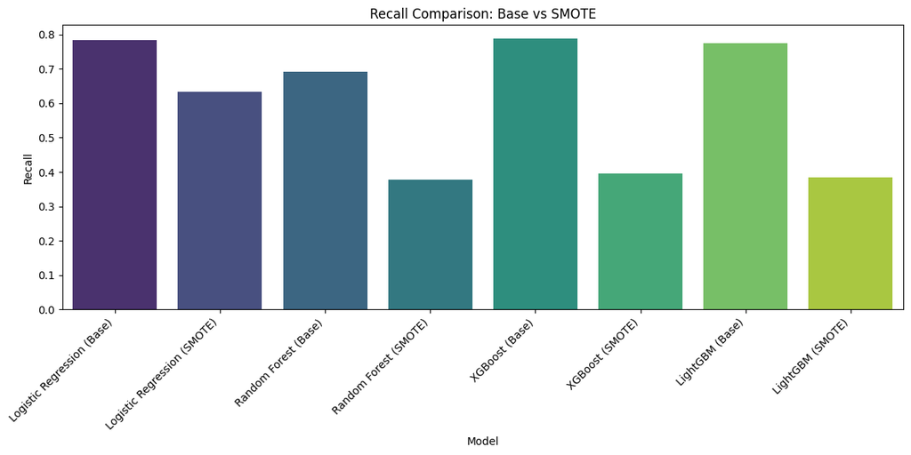

```python
# Summary of all models
results = pd.DataFrame(model_performance)

# Sort by Recall (descending) to see which model catches the most fraud
results_sorted = results.sort_values(by='Recall', ascending=False)

print("--- Model Performance Comparison ---")
print(results_sorted.to_string(index=False))

# Optional: Plotting
import matplotlib.pyplot as plt
import seaborn as sns

plt.figure(figsize=(12, 6))
sns.barplot(data=results, x='Model', y='Recall', palette='viridis')
plt.title('Recall Comparison: Base vs SMOTE')
plt.xticks(rotation=45, ha='right')
plt.tight_layout()
plt.show()
```